# Risk Factor Analysis

## Outcome Variable

**Outcome Variable:** ever_stunted

## Predictor Variables

**Intervention Variable:** tr

**Adjustment Set:**

unadjusted

## Stratifying Variables

The analysis was stratified on these variable(s):

- safeh20
- agecat
- studyid
- country

## Data Summary

| safeh20 | agecat | studyid | country | tr | ever_stunted | n_cell | n |
| --- | --- | --- | --- | --- | --- | --- | --- |
| 1 | 0-6 months | ki1000125-AgaKhanUniv | PAKISTAN | Control | 0 | 98 | 290 |
| 1 | 0-6 months | ki1000125-AgaKhanUniv | PAKISTAN | Control | 1 | 40 | 290 |
| 1 | 0-6 months | ki1000125-AgaKhanUniv | PAKISTAN | Maternal | 0 | 115 | 290 |
| 1 | 0-6 months | ki1000125-AgaKhanUniv | PAKISTAN | Maternal | 1 | 37 | 290 |
| 1 | 0-6 months | ki1000304-VITAMIN-A | INDIA | Control | 0 | 118 | 334 |
| 1 | 0-6 months | ki1000304-VITAMIN-A | INDIA | Control | 1 | 53 | 334 |
| 1 | 0-6 months | ki1000304-VITAMIN-A | INDIA | VitA | 0 | 109 | 334 |
| 1 | 0-6 months | ki1000304-VITAMIN-A | INDIA | VitA | 1 | 54 | 334 |
| 1 | 0-6 months | ki1000304-ZnMort | INDIA | Control | 0 | 45 | 152 |
| 1 | 0-6 months | ki1000304-ZnMort | INDIA | Control | 1 | 28 | 152 |
| 1 | 0-6 months | ki1000304-ZnMort | INDIA | Zinc | 0 | 48 | 152 |
| 1 | 0-6 months | ki1000304-ZnMort | INDIA | Zinc | 1 | 31 | 152 |
| 1 | 0-6 months | ki1000304b-SAS-FoodSuppl | INDIA | Control | 0 | 63 | 416 |
| 1 | 0-6 months | ki1000304b-SAS-FoodSuppl | INDIA | Control | 1 | 42 | 416 |
| 1 | 0-6 months | ki1000304b-SAS-FoodSuppl | INDIA | Other | 0 | 194 | 416 |
| 1 | 0-6 months | ki1000304b-SAS-FoodSuppl | INDIA | Other | 1 | 117 | 416 |
| 1 | 0-6 months | ki1017093b-PROVIDE | BANGLADESH | Control | 0 | 142 | 638 |
| 1 | 0-6 months | ki1017093b-PROVIDE | BANGLADESH | Control | 1 | 24 | 638 |
| 1 | 0-6 months | ki1017093b-PROVIDE | BANGLADESH | Other | 0 | 407 | 638 |
| 1 | 0-6 months | ki1017093b-PROVIDE | BANGLADESH | Other | 1 | 65 | 638 |
| 0 | 0-6 months | ki1112895-Burkina Faso Zn | BURKINA FASO | Zinc | 0 | 20 | 24 |
| 0 | 0-6 months | ki1112895-Burkina Faso Zn | BURKINA FASO | Zinc | 1 | 4 | 24 |
| 1 | 0-6 months | ki1112895-Burkina Faso Zn | BURKINA FASO | Zinc | 0 | 13 | 14 |
| 1 | 0-6 months | ki1112895-Burkina Faso Zn | BURKINA FASO | Zinc | 1 | 1 | 14 |
| 1 | 0-6 months | ki1148112-iLiNS-DOSE | MALAWI | Control | 0 | 95 | 802 |
| 1 | 0-6 months | ki1148112-iLiNS-DOSE | MALAWI | Control | 1 | 40 | 802 |
| 1 | 0-6 months | ki1148112-iLiNS-DOSE | MALAWI | LNS | 0 | 470 | 802 |
| 1 | 0-6 months | ki1148112-iLiNS-DOSE | MALAWI | LNS | 1 | 197 | 802 |
| 0 | 0-6 months | ki1148112-iLiNS-DOSE | MALAWI | Control | 0 | 3 | 57 |
| 0 | 0-6 months | ki1148112-iLiNS-DOSE | MALAWI | Control | 1 | 2 | 57 |

[output cut: 186 more lines]

The following strata were considered:

- safeh20: 0, agecat: 0-24 months, studyid: iLiNS_DYADM_LNS, country: MALAWI
- safeh20: 0, agecat: 0-24 months, studyid: ki1000304-VITAMIN-A, country: INDIA
- safeh20: 0, agecat: 0-24 months, studyid: ki1112895-Burkina Faso Zn, country: BURKINA FASO
- safeh20: 0, agecat: 0-24 months, studyid: ki1148112-iLiNS-DOSE, country: MALAWI
- safeh20: 0, agecat: 0-24 months, studyid: ki1148112-iLiNS-DYAD-M, country: MALAWI
- safeh20: 0, agecat: 0-24 months, studyid: ki1148112-LCNI-5, country: MALAWI
- safeh20: 0, agecat: 0-24 months, studyid: kiGH5241-JiVitA-3, country: BANGLADESH
- safeh20: 0, agecat: 0-24 months, studyid: kiGH5241-JiVitA-4, country: BANGLADESH
- safeh20: 0, agecat: 0-6 months, studyid: iLiNS_DYADM_LNS, country: MALAWI
- safeh20: 0, agecat: 0-6 months, studyid: ki1112895-Burkina Faso Zn, country: BURKINA FASO
- safeh20: 0, agecat: 0-6 months, studyid: ki1148112-iLiNS-DOSE, country: MALAWI
- safeh20: 0, agecat: 0-6 months, studyid: ki1148112-iLiNS-DYAD-M, country: MALAWI
- safeh20: 0, agecat: 0-6 months, studyid: ki1148112-LCNI-5, country: MALAWI
- safeh20: 0, agecat: 0-6 months, studyid: kiGH5241-JiVitA-3, country: BANGLADESH
- safeh20: 0, agecat: 0-6 months, studyid: kiGH5241-JiVitA-4, country: BANGLADESH
- safeh20: 0, agecat: 6-24 months, studyid: iLiNS_DYADM_LNS, country: MALAWI
- safeh20: 0, agecat: 6-24 months, studyid: ki1000304-VITAMIN-A, country: INDIA
- safeh20: 0, agecat: 6-24 months, studyid: ki1112895-Burkina Faso Zn, country: BURKINA FASO
- safeh20: 0, agecat: 6-24 months, studyid: ki1148112-iLiNS-DOSE, country: MALAWI
- safeh20: 0, agecat: 6-24 months, studyid: ki1148112-iLiNS-DYAD-M, country: MALAWI
- safeh20: 0, agecat: 6-24 months, studyid: ki1148112-LCNI-5, country: MALAWI
- safeh20: 0, agecat: 6-24 months, studyid: kiGH5241-JiVitA-3, country: BANGLADESH
- safeh20: 0, agecat: 6-24 months, studyid: kiGH5241-JiVitA-4, country: BANGLADESH
- safeh20: 1, agecat: 0-24 months, studyid: iLiNS_DYADM_LNS, country: MALAWI
- safeh20: 1, agecat: 0-24 months, studyid: ki1000125-AgaKhanUniv, country: PAKISTAN
- safeh20: 1, agecat: 0-24 months, studyid: ki1000304-VITAMIN-A, country: INDIA
- safeh20: 1, agecat: 0-24 months, studyid: ki1000304-ZnMort, country: INDIA
- safeh20: 1, agecat: 0-24 months, studyid: ki1000304b-SAS-FoodSuppl, country: INDIA
- safeh20: 1, agecat: 0-24 months, studyid: ki1017093b-PROVIDE, country: BANGLADESH
- safeh20: 1, agecat: 0-24 months, studyid: ki1112895-Burkina Faso Zn, country: BURKINA FASO
- safeh20: 1, agecat: 0-24 months, studyid: ki1148112-iLiNS-DOSE, country: MALAWI
- safeh20: 1, agecat: 0-24 months, studyid: ki1148112-iLiNS-DYAD-M, country: MALAWI
- safeh20: 1, agecat: 0-24 months, studyid: ki1148112-LCNI-5, country: MALAWI
- safeh20: 1, agecat: 0-24 months, studyid: kiGH5241-JiVitA-3, country: BANGLADESH
- safeh20: 1, agecat: 0-24 months, studyid: kiGH5241-JiVitA-4, country: BANGLADESH
- safeh20: 1, agecat: 0-6 months, studyid: iLiNS_DYADM_LNS, country: MALAWI
- safeh20: 1, agecat: 0-6 months, studyid: ki1000125-AgaKhanUniv, country: PAKISTAN
- safeh20: 1, agecat: 0-6 months, studyid: ki1000304-VITAMIN-A, country: INDIA
- safeh20: 1, agecat: 0-6 months, studyid: ki1000304-ZnMort, country: INDIA
- safeh20: 1, agecat: 0-6 months, studyid: ki1000304b-SAS-FoodSuppl, country: INDIA
- safeh20: 1, agecat: 0-6 months, studyid: ki1017093b-PROVIDE, country: BANGLADESH
- safeh20: 1, agecat: 0-6 months, studyid: ki1112895-Burkina Faso Zn, country: BURKINA FASO
- safeh20: 1, agecat: 0-6 months, studyid: ki1148112-iLiNS-DOSE, country: MALAWI
- safeh20: 1, agecat: 0-6 months, studyid: ki1148112-iLiNS-DYAD-M, country: MALAWI
- safeh20: 1, agecat: 0-6 months, studyid: ki1148112-LCNI-5, country: MALAWI
- safeh20: 1, agecat: 0-6 months, studyid: kiGH5241-JiVitA-3, country: BANGLADESH
- safeh20: 1, agecat: 0-6 months, studyid: kiGH5241-JiVitA-4, country: BANGLADESH
- safeh20: 1, agecat: 6-24 months, studyid: iLiNS_DYADM_LNS, country: MALAWI
- safeh20: 1, agecat: 6-24 months, studyid: ki1000125-AgaKhanUniv, country: PAKISTAN
- safeh20: 1, agecat: 6-24 months, studyid: ki1000304-VITAMIN-A, country: INDIA
- safeh20: 1, agecat: 6-24 months, studyid: ki1000304-ZnMort, country: INDIA
- safeh20: 1, agecat: 6-24 months, studyid: ki1000304b-SAS-FoodSuppl, country: INDIA
- safeh20: 1, agecat: 6-24 months, studyid: ki1017093b-PROVIDE, country: BANGLADESH
- safeh20: 1, agecat: 6-24 months, studyid: ki1112895-Burkina Faso Zn, country: BURKINA FASO
- safeh20: 1, agecat: 6-24 months, studyid: ki1148112-iLiNS-DOSE, country: MALAWI
- safeh20: 1, agecat: 6-24 months, studyid: ki1148112-iLiNS-DYAD-M, country: MALAWI
- safeh20: 1, agecat: 6-24 months, studyid: ki1148112-LCNI-5, country: MALAWI
- safeh20: 1, agecat: 6-24 months, studyid: kiGH5241-JiVitA-3, country: BANGLADESH
- safeh20: 1, agecat: 6-24 months, studyid: kiGH5241-JiVitA-4, country: BANGLADESH

### Dropped Strata

Some strata were dropped due to rare outcomes:

- safeh20: 0, agecat: 0-6 months, studyid: ki1112895-Burkina Faso Zn, country: BURKINA FASO
- safeh20: 1, agecat: 0-6 months, studyid: ki1112895-Burkina Faso Zn, country: BURKINA FASO
- safeh20: 0, agecat: 0-6 months, studyid: ki1148112-iLiNS-DOSE, country: MALAWI
- safeh20: 1, agecat: 0-6 months, studyid: ki1148112-iLiNS-DYAD-M, country: MALAWI
- safeh20: 0, agecat: 0-6 months, studyid: ki1148112-iLiNS-DYAD-M, country: MALAWI
- safeh20: 0, agecat: 0-6 months, studyid: ki1148112-LCNI-5, country: MALAWI
- safeh20: 0, agecat: 0-6 months, studyid: kiGH5241-JiVitA-4, country: BANGLADESH
- safeh20: 0, agecat: 6-24 months, studyid: ki1000304-VITAMIN-A, country: INDIA
- safeh20: 0, agecat: 6-24 months, studyid: ki1148112-iLiNS-DOSE, country: MALAWI
- safeh20: 1, agecat: 6-24 months, studyid: ki1148112-iLiNS-DYAD-M, country: MALAWI
- safeh20: 0, agecat: 6-24 months, studyid: ki1148112-iLiNS-DYAD-M, country: MALAWI
- safeh20: 0, agecat: 6-24 months, studyid: kiGH5241-JiVitA-3, country: BANGLADESH
- safeh20: 0, agecat: 6-24 months, studyid: kiGH5241-JiVitA-4, country: BANGLADESH
- safeh20: 0, agecat: 0-24 months, studyid: ki1000304-VITAMIN-A, country: INDIA
- safeh20: 0, agecat: 0-24 months, studyid: ki1148112-iLiNS-DYAD-M, country: MALAWI
- safeh20: 0, agecat: 0-24 months, studyid: kiGH5241-JiVitA-3, country: BANGLADESH
- safeh20: 0, agecat: 0-24 months, studyid: kiGH5241-JiVitA-4, country: BANGLADESH
- safeh20: 1, agecat: 0-6 months, studyid: iLiNS_DYADM_LNS, country: MALAWI
- safeh20: 0, agecat: 0-6 months, studyid: iLiNS_DYADM_LNS, country: MALAWI
- safeh20: 1, agecat: 6-24 months, studyid: iLiNS_DYADM_LNS, country: MALAWI
- safeh20: 0, agecat: 6-24 months, studyid: iLiNS_DYADM_LNS, country: MALAWI
- safeh20: 0, agecat: 0-24 months, studyid: iLiNS_DYADM_LNS, country: MALAWI

## Methods Detail

We’re interested in the causal parameters $E[Y_a]$ for all values of $a \in \mathcal{A}$. These parameters represent the mean outcome if, possibly contrary to fact, we intervened to set all units to have $A=a$. Under the randomization and positivity assumptions, these are identified by the statistical parameters $\psi_a=E_W[E_{Y|A,W}(Y|A=a,W)]$. In addition, we’re interested in the mean of $Y$, $E[Y]$ under no intervention (the observed mean). We will estimate these parameters by using SuperLearner to fit the relevant likelihood factors – $E_{Y|A,W}(Y|A=a,W)$ and $p(A=a|W)$, and then updating our likelihood fit using a joint TMLE.

For unadjusted analyses ($W=\{\}$), initial likelihoods were estimated using Lrnr_glm to estimate the simple $E(Y|A)$ and Lrnr_mean to estimate $p(A)$. For adjusted analyses, a small library containing Lrnr_glmnet, Lrnr_xgboost, and Lrnr_mean was used.

Having estimated these parameters, we will then use the delta method to estimate relative risks and attributable risks relative to a prespecified baseline level of $A$.

[output not shown]

# Results Detail

## Results Plots

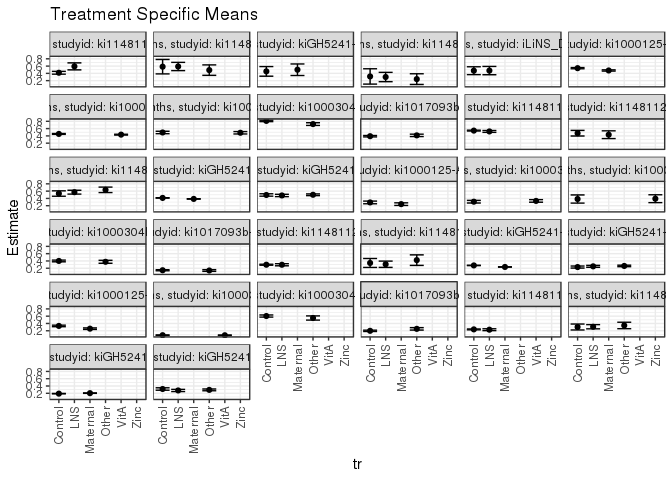

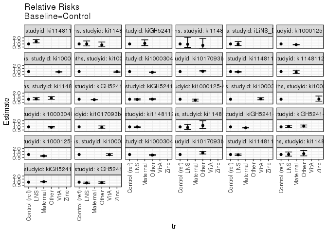

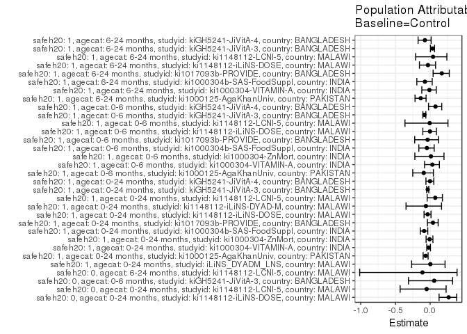

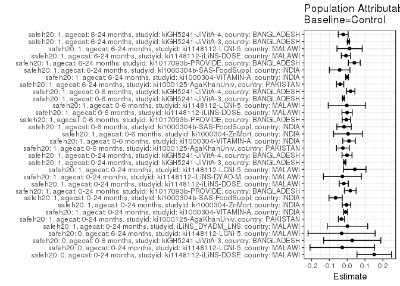

## Results Table

### Parameter: TSM

| safeh20 | agecat | studyid | country | intervention_level | baseline_level | estimate | ci_lower | ci_upper |
| --- | --- | --- | --- | --- | --- | --- | --- | --- |
| 0 | 0-24 months | ki1148112-iLiNS-DOSE | MALAWI | Control | NA | 0.4166667 | 0.3784115 | 0.4549219 |
| 0 | 0-24 months | ki1148112-iLiNS-DOSE | MALAWI | LNS | NA | 0.5921053 | 0.4961370 | 0.6880735 |
| 0 | 0-24 months | ki1148112-LCNI-5 | MALAWI | Control | NA | 0.5833333 | 0.3854048 | 0.7812619 |
| 0 | 0-24 months | ki1148112-LCNI-5 | MALAWI | LNS | NA | 0.5890411 | 0.4757823 | 0.7022999 |
| 0 | 0-24 months | ki1148112-LCNI-5 | MALAWI | Other | NA | 0.4893617 | 0.3459502 | 0.6327732 |
| 0 | 0-6 months | kiGH5241-JiVitA-3 | BANGLADESH | Control | NA | 0.4545455 | 0.3220797 | 0.5870112 |
| 0 | 0-6 months | kiGH5241-JiVitA-3 | BANGLADESH | Maternal | NA | 0.5000000 | 0.3415951 | 0.6584049 |
| 0 | 6-24 months | ki1148112-LCNI-5 | MALAWI | Control | NA | 0.3157895 | 0.1057483 | 0.5258306 |
| 0 | 6-24 months | ki1148112-LCNI-5 | MALAWI | LNS | NA | 0.3000000 | 0.1723526 | 0.4276474 |
| 0 | 6-24 months | ki1148112-LCNI-5 | MALAWI | Other | NA | 0.2424242 | 0.0954871 | 0.3893614 |
| 1 | 0-24 months | iLiNS_DYADM_LNS | MALAWI | Control | NA | 0.4736842 | 0.3656826 | 0.5816858 |
| 1 | 0-24 months | iLiNS_DYADM_LNS | MALAWI | LNS | NA | 0.4761905 | 0.3626182 | 0.5897628 |
| 1 | 0-24 months | ki1000125-AgaKhanUniv | PAKISTAN | Control | NA | 0.5428227 | 0.5264354 | 0.5592099 |
| 1 | 0-24 months | ki1000125-AgaKhanUniv | PAKISTAN | Maternal | NA | 0.4791432 | 0.4621447 | 0.4961417 |
| 1 | 0-24 months | ki1000304-VITAMIN-A | INDIA | Control | NA | 0.4535274 | 0.4418707 | 0.4651842 |
| 1 | 0-24 months | ki1000304-VITAMIN-A | INDIA | VitA | NA | 0.4343607 | 0.4228656 | 0.4458559 |
| 1 | 0-24 months | ki1000304-ZnMort | INDIA | Control | NA | 0.4935370 | 0.4599368 | 0.5271372 |
| 1 | 0-24 months | ki1000304-ZnMort | INDIA | Zinc | NA | 0.4859076 | 0.4530066 | 0.5188085 |
| 1 | 0-24 months | ki1000304b-SAS-FoodSuppl | INDIA | Control | NA | 0.8113208 | 0.7924102 | 0.8302313 |
| 1 | 0-24 months | ki1000304b-SAS-FoodSuppl | INDIA | Other | NA | 0.7243590 | 0.6873064 | 0.7614115 |
| 1 | 0-24 months | ki1017093b-PROVIDE | BANGLADESH | Control | NA | 0.3915663 | 0.3722621 | 0.4108704 |
| 1 | 0-24 months | ki1017093b-PROVIDE | BANGLADESH | Other | NA | 0.4143763 | 0.3814893 | 0.4472634 |
| 1 | 0-24 months | ki1148112-iLiNS-DOSE | MALAWI | Control | NA | 0.5450237 | 0.5335115 | 0.5565359 |
| 1 | 0-24 months | ki1148112-iLiNS-DOSE | MALAWI | LNS | NA | 0.5220372 | 0.4966348 | 0.5474396 |
| 1 | 0-24 months | ki1148112-iLiNS-DYAD-M | MALAWI | Control | NA | 0.4736842 | 0.3968212 | 0.5505472 |
| 1 | 0-24 months | ki1148112-iLiNS-DYAD-M | MALAWI | Maternal | NA | 0.4324324 | 0.3260080 | 0.5388569 |
| 1 | 0-24 months | ki1148112-LCNI-5 | MALAWI | Control | NA | 0.5340909 | 0.4603391 | 0.6078427 |
| 1 | 0-24 months | ki1148112-LCNI-5 | MALAWI | LNS | NA | 0.5710059 | 0.5182029 | 0.6238089 |
| 1 | 0-24 months | ki1148112-LCNI-5 | MALAWI | Other | NA | 0.6352201 | 0.5603429 | 0.7100974 |
| 1 | 0-24 months | kiGH5241-JiVitA-3 | BANGLADESH | Control | NA | 0.4136287 | 0.4077637 | 0.4194938 |
| 1 | 0-24 months | kiGH5241-JiVitA-3 | BANGLADESH | Maternal | NA | 0.3862063 | 0.3805744 | 0.3918382 |
| 1 | 0-24 months | kiGH5241-JiVitA-4 | BANGLADESH | Control | NA | 0.4944056 | 0.4613621 | 0.5274491 |
| 1 | 0-24 months | kiGH5241-JiVitA-4 | BANGLADESH | LNS | NA | 0.4812081 | 0.4495682 | 0.5128479 |
| 1 | 0-24 months | kiGH5241-JiVitA-4 | BANGLADESH | Other | NA | 0.5000000 | 0.4767125 | 0.5232875 |
| 1 | 0-6 months | ki1000125-AgaKhanUniv | PAKISTAN | Control | NA | 0.2898551 | 0.2537720 | 0.3259382 |
| 1 | 0-6 months | ki1000125-AgaKhanUniv | PAKISTAN | Maternal | NA | 0.2434211 | 0.2076008 | 0.2792413 |
| 1 | 0-6 months | ki1000304-VITAMIN-A | INDIA | Control | NA | 0.3099415 | 0.2744002 | 0.3454828 |
| 1 | 0-6 months | ki1000304-VITAMIN-A | INDIA | VitA | NA | 0.3312883 | 0.2959725 | 0.3666041 |
| 1 | 0-6 months | ki1000304-ZnMort | INDIA | Control | NA | 0.3835616 | 0.2716482 | 0.4954751 |
| 1 | 0-6 months | ki1000304-ZnMort | INDIA | Zinc | NA | 0.3924051 | 0.2843756 | 0.5004345 |
| 1 | 0-6 months | ki1000304b-SAS-FoodSuppl | INDIA | Control | NA | 0.4000000 | 0.3763202 | 0.4236798 |
| 1 | 0-6 months | ki1000304b-SAS-FoodSuppl | INDIA | Other | NA | 0.3762058 | 0.3359071 | 0.4165045 |
| 1 | 0-6 months | ki1017093b-PROVIDE | BANGLADESH | Control | NA | 0.1445783 | 0.1306479 | 0.1585087 |
| 1 | 0-6 months | ki1017093b-PROVIDE | BANGLADESH | Other | NA | 0.1377119 | 0.1146947 | 0.1607290 |
| 1 | 0-6 months | ki1148112-iLiNS-DOSE | MALAWI | Control | NA | 0.2962963 | 0.2833224 | 0.3092702 |
| 1 | 0-6 months | ki1148112-iLiNS-DOSE | MALAWI | LNS | NA | 0.2953523 | 0.2665410 | 0.3241637 |
| 1 | 0-6 months | ki1148112-LCNI-5 | MALAWI | Control | NA | 0.3448276 | 0.2222151 | 0.4674401 |
| 1 | 0-6 months | ki1148112-LCNI-5 | MALAWI | LNS | NA | 0.3090909 | 0.2225289 | 0.3956529 |
| 1 | 0-6 months | ki1148112-LCNI-5 | MALAWI | Other | NA | 0.4222222 | 0.2775735 | 0.5668710 |
| 1 | 0-6 months | kiGH5241-JiVitA-3 | BANGLADESH | Control | NA | 0.2768444 | 0.2715779 | 0.2821110 |
| 1 | 0-6 months | kiGH5241-JiVitA-3 | BANGLADESH | Maternal | NA | 0.2346656 | 0.2299864 | 0.2393447 |
| 1 | 0-6 months | kiGH5241-JiVitA-4 | BANGLADESH | Control | NA | 0.2324003 | 0.2045483 | 0.2602524 |
| 1 | 0-6 months | kiGH5241-JiVitA-4 | BANGLADESH | LNS | NA | 0.2518043 | 0.2261921 | 0.2774165 |
| 1 | 0-6 months | kiGH5241-JiVitA-4 | BANGLADESH | Other | NA | 0.2624413 | 0.2416071 | 0.2832756 |
| 1 | 6-24 months | ki1000125-AgaKhanUniv | PAKISTAN | Control | NA | 0.3325893 | 0.3119830 | 0.3531956 |
| 1 | 6-24 months | ki1000125-AgaKhanUniv | PAKISTAN | Maternal | NA | 0.2574850 | 0.2372614 | 0.2777086 |
| 1 | 6-24 months | ki1000304-VITAMIN-A | INDIA | Control | NA | 0.0779944 | 0.0700219 | 0.0859670 |
| 1 | 6-24 months | ki1000304-VITAMIN-A | INDIA | VitA | NA | 0.0763569 | 0.0684250 | 0.0842889 |
| 1 | 6-24 months | ki1000304b-SAS-FoodSuppl | INDIA | Control | NA | 0.6041667 | 0.5747185 | 0.6336148 |
| 1 | 6-24 months | ki1000304b-SAS-FoodSuppl | INDIA | Other | NA | 0.5505618 | 0.4928784 | 0.6082452 |
| 1 | 6-24 months | ki1017093b-PROVIDE | BANGLADESH | Control | NA | 0.1984127 | 0.1806697 | 0.2161557 |
| 1 | 6-24 months | ki1017093b-PROVIDE | BANGLADESH | Other | NA | 0.2520325 | 0.2189754 | 0.2850896 |
| 1 | 6-24 months | ki1148112-iLiNS-DOSE | MALAWI | Control | NA | 0.2377622 | 0.2258343 | 0.2496902 |
| 1 | 6-24 months | ki1148112-iLiNS-DOSE | MALAWI | LNS | NA | 0.2291066 | 0.2031662 | 0.2550471 |
| 1 | 6-24 months | ki1148112-LCNI-5 | MALAWI | Control | NA | 0.3032787 | 0.2216253 | 0.3849321 |
| 1 | 6-24 months | ki1148112-LCNI-5 | MALAWI | LNS | NA | 0.3102041 | 0.2522205 | 0.3681876 |
| 1 | 6-24 months | ki1148112-LCNI-5 | MALAWI | Other | NA | 0.3454545 | 0.2564990 | 0.4344100 |
| 1 | 6-24 months | kiGH5241-JiVitA-3 | BANGLADESH | Control | NA | 0.1901311 | 0.1847144 | 0.1955478 |
| 1 | 6-24 months | kiGH5241-JiVitA-3 | BANGLADESH | Maternal | NA | 0.2033824 | 0.1973963 | 0.2093684 |
| 1 | 6-24 months | kiGH5241-JiVitA-4 | BANGLADESH | Control | NA | 0.3177489 | 0.2847469 | 0.3507509 |
| 1 | 6-24 months | kiGH5241-JiVitA-4 | BANGLADESH | LNS | NA | 0.2774518 | 0.2475129 | 0.3073907 |
| 1 | 6-24 months | kiGH5241-JiVitA-4 | BANGLADESH | Other | NA | 0.2933061 | 0.2692823 | 0.3173299 |

### Parameter: E(Y)

| safeh20 | agecat | studyid | country | intervention_level | baseline_level | estimate | ci_lower | ci_upper |
| --- | --- | --- | --- | --- | --- | --- | --- | --- |
| 0 | 0-24 months | ki1148112-iLiNS-DOSE | MALAWI | NA | NA | 0.5681818 | 0.4640981 | 0.6722655 |
| 0 | 0-24 months | ki1148112-LCNI-5 | MALAWI | NA | NA | 0.5555556 | 0.4741128 | 0.6369983 |
| 0 | 0-6 months | kiGH5241-JiVitA-3 | BANGLADESH | NA | NA | 0.4827586 | 0.2694802 | 0.6960370 |
| 0 | 6-24 months | ki1148112-LCNI-5 | MALAWI | NA | NA | 0.2843137 | 0.1963411 | 0.3722864 |
| 1 | 0-24 months | iLiNS_DYADM_LNS | MALAWI | NA | NA | 0.4750000 | 0.3182736 | 0.6317264 |
| 1 | 0-24 months | ki1000125-AgaKhanUniv | PAKISTAN | NA | NA | 0.5099068 | 0.4862475 | 0.5335660 |
| 1 | 0-24 months | ki1000304-VITAMIN-A | INDIA | NA | NA | 0.4440362 | 0.4276619 | 0.4604105 |
| 1 | 0-24 months | ki1000304-ZnMort | INDIA | NA | NA | 0.4896433 | 0.4661348 | 0.5131518 |
| 1 | 0-24 months | ki1000304b-SAS-FoodSuppl | INDIA | NA | NA | 0.7464115 | 0.7046540 | 0.7881689 |
| 1 | 0-24 months | ki1017093b-PROVIDE | BANGLADESH | NA | NA | 0.4084507 | 0.3703087 | 0.4465927 |
| 1 | 0-24 months | ki1148112-iLiNS-DOSE | MALAWI | NA | NA | 0.5259740 | 0.4980806 | 0.5538675 |
| 1 | 0-24 months | ki1148112-iLiNS-DYAD-M | MALAWI | NA | NA | 0.4464286 | 0.3150485 | 0.5778087 |
| 1 | 0-24 months | ki1148112-LCNI-5 | MALAWI | NA | NA | 0.5765230 | 0.5391648 | 0.6138813 |
| 1 | 0-24 months | kiGH5241-JiVitA-3 | BANGLADESH | NA | NA | 0.3997815 | 0.3915546 | 0.4080085 |
| 1 | 0-24 months | kiGH5241-JiVitA-4 | BANGLADESH | NA | NA | 0.4933628 | 0.4770166 | 0.5097090 |
| 1 | 0-6 months | ki1000125-AgaKhanUniv | PAKISTAN | NA | NA | 0.2655172 | 0.2146033 | 0.3164311 |
| 1 | 0-6 months | ki1000304-VITAMIN-A | INDIA | NA | NA | 0.3203593 | 0.2702424 | 0.3704762 |
| 1 | 0-6 months | ki1000304-ZnMort | INDIA | NA | NA | 0.3881579 | 0.3104288 | 0.4658870 |
| 1 | 0-6 months | ki1000304b-SAS-FoodSuppl | INDIA | NA | NA | 0.3822115 | 0.3354600 | 0.4289631 |
| 1 | 0-6 months | ki1017093b-PROVIDE | BANGLADESH | NA | NA | 0.1394984 | 0.1125931 | 0.1664038 |
| 1 | 0-6 months | ki1148112-iLiNS-DOSE | MALAWI | NA | NA | 0.2955112 | 0.2639135 | 0.3271090 |
| 1 | 0-6 months | ki1148112-LCNI-5 | MALAWI | NA | NA | 0.3427230 | 0.2788340 | 0.4066120 |
| 1 | 0-6 months | kiGH5241-JiVitA-3 | BANGLADESH | NA | NA | 0.2555912 | 0.2483463 | 0.2628362 |
| 1 | 0-6 months | kiGH5241-JiVitA-4 | BANGLADESH | NA | NA | 0.2517559 | 0.2377073 | 0.2658045 |
| 1 | 6-24 months | ki1000125-AgaKhanUniv | PAKISTAN | NA | NA | 0.2929399 | 0.2639691 | 0.3219108 |
| 1 | 6-24 months | ki1000304-VITAMIN-A | INDIA | NA | NA | 0.0771719 | 0.0659256 | 0.0884182 |
| 1 | 6-24 months | ki1000304b-SAS-FoodSuppl | INDIA | NA | NA | 0.5619469 | 0.4971181 | 0.6267757 |
| 1 | 6-24 months | ki1017093b-PROVIDE | BANGLADESH | NA | NA | 0.2383838 | 0.2008095 | 0.2759582 |
| 1 | 6-24 months | ki1148112-iLiNS-DOSE | MALAWI | NA | NA | 0.2305854 | 0.2020331 | 0.2591377 |
| 1 | 6-24 months | ki1148112-LCNI-5 | MALAWI | NA | NA | 0.3165618 | 0.2747765 | 0.3583471 |
| 1 | 6-24 months | kiGH5241-JiVitA-3 | BANGLADESH | NA | NA | 0.1969138 | 0.1888431 | 0.2049845 |
| 1 | 6-24 months | kiGH5241-JiVitA-4 | BANGLADESH | NA | NA | 0.2954704 | 0.2791021 | 0.3118386 |

### Parameter: RR

| safeh20 | agecat | studyid | country | intervention_level | baseline_level | estimate | ci_lower | ci_upper |
| --- | --- | --- | --- | --- | --- | --- | --- | --- |
| 0 | 0-24 months | ki1148112-iLiNS-DOSE | MALAWI | Control | Control | 1.0000000 | 1.0000000 | 1.0000000 |
| 0 | 0-24 months | ki1148112-iLiNS-DOSE | MALAWI | LNS | Control | 1.4210526 | 1.1795350 | 1.7120226 |
| 0 | 0-24 months | ki1148112-LCNI-5 | MALAWI | Control | Control | 1.0000000 | 1.0000000 | 1.0000000 |
| 0 | 0-24 months | ki1148112-LCNI-5 | MALAWI | LNS | Control | 1.0097847 | 0.6836827 | 1.4914306 |
| 0 | 0-24 months | ki1148112-LCNI-5 | MALAWI | Other | Control | 0.8389058 | 0.5357968 | 1.3134885 |
| 0 | 0-6 months | kiGH5241-JiVitA-3 | BANGLADESH | Control | Control | 1.0000000 | 1.0000000 | 1.0000000 |
| 0 | 0-6 months | kiGH5241-JiVitA-3 | BANGLADESH | Maternal | Control | 1.1000000 | 0.7210378 | 1.6781367 |
| 0 | 6-24 months | ki1148112-LCNI-5 | MALAWI | Control | Control | 1.0000000 | 1.0000000 | 1.0000000 |
| 0 | 6-24 months | ki1148112-LCNI-5 | MALAWI | LNS | Control | 0.9500000 | 0.4313324 | 2.0923539 |
| 0 | 6-24 months | ki1148112-LCNI-5 | MALAWI | Other | Control | 0.7676768 | 0.3121532 | 1.8879437 |
| 1 | 0-24 months | iLiNS_DYADM_LNS | MALAWI | Control | Control | 1.0000000 | 1.0000000 | 1.0000000 |
| 1 | 0-24 months | iLiNS_DYADM_LNS | MALAWI | LNS | Control | 1.0052910 | 0.7227618 | 1.3982614 |
| 1 | 0-24 months | ki1000125-AgaKhanUniv | PAKISTAN | Control | Control | 1.0000000 | 1.0000000 | 1.0000000 |
| 1 | 0-24 months | ki1000125-AgaKhanUniv | PAKISTAN | Maternal | Control | 0.8826882 | 0.8425129 | 0.9247793 |
| 1 | 0-24 months | ki1000304-VITAMIN-A | INDIA | Control | Control | 1.0000000 | 1.0000000 | 1.0000000 |
| 1 | 0-24 months | ki1000304-VITAMIN-A | INDIA | VitA | Control | 0.9577386 | 0.9230500 | 0.9937309 |
| 1 | 0-24 months | ki1000304-ZnMort | INDIA | Control | Control | 1.0000000 | 1.0000000 | 1.0000000 |
| 1 | 0-24 months | ki1000304-ZnMort | INDIA | Zinc | Control | 0.9845413 | 0.8944034 | 1.0837632 |
| 1 | 0-24 months | ki1000304b-SAS-FoodSuppl | INDIA | Control | Control | 1.0000000 | 1.0000000 | 1.0000000 |
| 1 | 0-24 months | ki1000304b-SAS-FoodSuppl | INDIA | Other | Control | 0.8928145 | 0.8440119 | 0.9444391 |
| 1 | 0-24 months | ki1017093b-PROVIDE | BANGLADESH | Control | Control | 1.0000000 | 1.0000000 | 1.0000000 |
| 1 | 0-24 months | ki1017093b-PROVIDE | BANGLADESH | Other | Control | 1.0582534 | 0.9638584 | 1.1618929 |
| 1 | 0-24 months | ki1148112-iLiNS-DOSE | MALAWI | Control | Control | 1.0000000 | 1.0000000 | 1.0000000 |
| 1 | 0-24 months | ki1148112-iLiNS-DOSE | MALAWI | LNS | Control | 0.9578248 | 0.9083394 | 1.0100061 |
| 1 | 0-24 months | ki1148112-iLiNS-DYAD-M | MALAWI | Control | Control | 1.0000000 | 1.0000000 | 1.0000000 |
| 1 | 0-24 months | ki1148112-iLiNS-DYAD-M | MALAWI | Maternal | Control | 0.9129129 | 0.6798380 | 1.2258951 |
| 1 | 0-24 months | ki1148112-LCNI-5 | MALAWI | Control | Control | 1.0000000 | 1.0000000 | 1.0000000 |
| 1 | 0-24 months | ki1148112-LCNI-5 | MALAWI | LNS | Control | 1.0691175 | 0.9054180 | 1.2624138 |
| 1 | 0-24 months | ki1148112-LCNI-5 | MALAWI | Other | Control | 1.1893483 | 0.9918809 | 1.4261283 |
| 1 | 0-24 months | kiGH5241-JiVitA-3 | BANGLADESH | Control | Control | 1.0000000 | 1.0000000 | 1.0000000 |
| 1 | 0-24 months | kiGH5241-JiVitA-3 | BANGLADESH | Maternal | Control | 0.9337028 | 0.9148868 | 0.9529057 |
| 1 | 0-24 months | kiGH5241-JiVitA-4 | BANGLADESH | Control | Control | 1.0000000 | 1.0000000 | 1.0000000 |
| 1 | 0-24 months | kiGH5241-JiVitA-4 | BANGLADESH | LNS | Control | 0.9733062 | 0.8861662 | 1.0690151 |
| 1 | 0-24 months | kiGH5241-JiVitA-4 | BANGLADESH | Other | Control | 1.0113154 | 0.9321721 | 1.0971782 |
| 1 | 0-6 months | ki1000125-AgaKhanUniv | PAKISTAN | Control | Control | 1.0000000 | 1.0000000 | 1.0000000 |
| 1 | 0-6 months | ki1000125-AgaKhanUniv | PAKISTAN | Maternal | Control | 0.8398026 | 0.6925780 | 1.0183235 |
| 1 | 0-6 months | ki1000304-VITAMIN-A | INDIA | Control | Control | 1.0000000 | 1.0000000 | 1.0000000 |
| 1 | 0-6 months | ki1000304-VITAMIN-A | INDIA | VitA | Control | 1.0688737 | 0.9139661 | 1.2500365 |
| 1 | 0-6 months | ki1000304-ZnMort | INDIA | Control | Control | 1.0000000 | 1.0000000 | 1.0000000 |
| 1 | 0-6 months | ki1000304-ZnMort | INDIA | Zinc | Control | 1.0230561 | 0.6849854 | 1.5279795 |
| 1 | 0-6 months | ki1000304b-SAS-FoodSuppl | INDIA | Control | Control | 1.0000000 | 1.0000000 | 1.0000000 |
| 1 | 0-6 months | ki1000304b-SAS-FoodSuppl | INDIA | Other | Control | 0.9405145 | 0.8321713 | 1.0629632 |
| 1 | 0-6 months | ki1017093b-PROVIDE | BANGLADESH | Control | Control | 1.0000000 | 1.0000000 | 1.0000000 |
| 1 | 0-6 months | ki1017093b-PROVIDE | BANGLADESH | Other | Control | 0.9525071 | 0.7853852 | 1.1551907 |
| 1 | 0-6 months | ki1148112-iLiNS-DOSE | MALAWI | Control | Control | 1.0000000 | 1.0000000 | 1.0000000 |
| 1 | 0-6 months | ki1148112-iLiNS-DOSE | MALAWI | LNS | Control | 0.9968141 | 0.8957296 | 1.1093062 |
| 1 | 0-6 months | ki1148112-LCNI-5 | MALAWI | Control | Control | 1.0000000 | 1.0000000 | 1.0000000 |
| 1 | 0-6 months | ki1148112-LCNI-5 | MALAWI | LNS | Control | 0.8963636 | 0.5700515 | 1.4094653 |
| 1 | 0-6 months | ki1148112-LCNI-5 | MALAWI | Other | Control | 1.2244444 | 0.7473096 | 2.0062155 |
| 1 | 0-6 months | kiGH5241-JiVitA-3 | BANGLADESH | Control | Control | 1.0000000 | 1.0000000 | 1.0000000 |
| 1 | 0-6 months | kiGH5241-JiVitA-3 | BANGLADESH | Maternal | Control | 0.8476442 | 0.8245922 | 0.8713407 |
| 1 | 0-6 months | kiGH5241-JiVitA-4 | BANGLADESH | Control | Control | 1.0000000 | 1.0000000 | 1.0000000 |
| 1 | 0-6 months | kiGH5241-JiVitA-4 | BANGLADESH | LNS | Control | 1.0834938 | 0.9258356 | 1.2679992 |
| 1 | 0-6 months | kiGH5241-JiVitA-4 | BANGLADESH | Other | Control | 1.1292639 | 0.9780620 | 1.3038406 |
| 1 | 6-24 months | ki1000125-AgaKhanUniv | PAKISTAN | Control | Control | 1.0000000 | 1.0000000 | 1.0000000 |
| 1 | 6-24 months | ki1000125-AgaKhanUniv | PAKISTAN | Maternal | Control | 0.7741832 | 0.7004830 | 0.8556376 |
| 1 | 6-24 months | ki1000304-VITAMIN-A | INDIA | Control | Control | 1.0000000 | 1.0000000 | 1.0000000 |
| 1 | 6-24 months | ki1000304-VITAMIN-A | INDIA | VitA | Control | 0.9790051 | 0.8462353 | 1.1326059 |
| 1 | 6-24 months | ki1000304b-SAS-FoodSuppl | INDIA | Control | Control | 1.0000000 | 1.0000000 | 1.0000000 |
| 1 | 6-24 months | ki1000304b-SAS-FoodSuppl | INDIA | Other | Control | 0.9112747 | 0.8118289 | 1.0229022 |
| 1 | 6-24 months | ki1017093b-PROVIDE | BANGLADESH | Control | Control | 1.0000000 | 1.0000000 | 1.0000000 |
| 1 | 6-24 months | ki1017093b-PROVIDE | BANGLADESH | Other | Control | 1.2702439 | 1.0837887 | 1.4887769 |
| 1 | 6-24 months | ki1148112-iLiNS-DOSE | MALAWI | Control | Control | 1.0000000 | 1.0000000 | 1.0000000 |
| 1 | 6-24 months | ki1148112-iLiNS-DOSE | MALAWI | LNS | Control | 0.9635955 | 0.8513563 | 1.0906319 |
| 1 | 6-24 months | ki1148112-LCNI-5 | MALAWI | Control | Control | 1.0000000 | 1.0000000 | 1.0000000 |
| 1 | 6-24 months | ki1148112-LCNI-5 | MALAWI | LNS | Control | 1.0228351 | 0.7369888 | 1.4195488 |
| 1 | 6-24 months | ki1148112-LCNI-5 | MALAWI | Other | Control | 1.1390663 | 0.7847864 | 1.6532807 |
| 1 | 6-24 months | kiGH5241-JiVitA-3 | BANGLADESH | Control | Control | 1.0000000 | 1.0000000 | 1.0000000 |
| 1 | 6-24 months | kiGH5241-JiVitA-3 | BANGLADESH | Maternal | Control | 1.0696955 | 1.0267565 | 1.1144303 |
| 1 | 6-24 months | kiGH5241-JiVitA-4 | BANGLADESH | Control | Control | 1.0000000 | 1.0000000 | 1.0000000 |
| 1 | 6-24 months | kiGH5241-JiVitA-4 | BANGLADESH | LNS | Control | 0.8731794 | 0.7517202 | 1.0142633 |
| 1 | 6-24 months | kiGH5241-JiVitA-4 | BANGLADESH | Other | Control | 0.9230750 | 0.8087142 | 1.0536077 |

### Parameter: PAR

| safeh20 | agecat | studyid | country | intervention_level | baseline_level | estimate | ci_lower | ci_upper |
| --- | --- | --- | --- | --- | --- | --- | --- | --- |
| 0 | 0-24 months | ki1148112-iLiNS-DOSE | MALAWI | Control | NA | 0.1515152 | 0.0547167 | 0.2483137 |
| 0 | 0-24 months | ki1148112-LCNI-5 | MALAWI | Control | NA | -0.0277778 | -0.2087476 | 0.1531920 |
| 0 | 0-6 months | kiGH5241-JiVitA-3 | BANGLADESH | Control | NA | 0.0282132 | -0.1321028 | 0.1885291 |
| 0 | 6-24 months | ki1148112-LCNI-5 | MALAWI | Control | NA | -0.0314757 | -0.2196794 | 0.1567279 |
| 1 | 0-24 months | iLiNS_DYADM_LNS | MALAWI | Control | NA | 0.0013158 | -0.1122572 | 0.1148888 |
| 1 | 0-24 months | ki1000125-AgaKhanUniv | PAKISTAN | Control | NA | -0.0329159 | -0.0499810 | -0.0158508 |
| 1 | 0-24 months | ki1000304-VITAMIN-A | INDIA | Control | NA | -0.0094913 | -0.0209907 | 0.0020082 |
| 1 | 0-24 months | ki1000304-ZnMort | INDIA | Control | NA | -0.0038937 | -0.0278945 | 0.0201070 |
| 1 | 0-24 months | ki1000304b-SAS-FoodSuppl | INDIA | Control | NA | -0.0649093 | -0.1021393 | -0.0276792 |
| 1 | 0-24 months | ki1017093b-PROVIDE | BANGLADESH | Control | NA | 0.0168844 | -0.0160117 | 0.0497806 |
| 1 | 0-24 months | ki1148112-iLiNS-DOSE | MALAWI | Control | NA | -0.0190497 | -0.0444567 | 0.0063573 |
| 1 | 0-24 months | ki1148112-iLiNS-DYAD-M | MALAWI | Control | NA | -0.0272556 | -0.1338052 | 0.0792939 |
| 1 | 0-24 months | ki1148112-LCNI-5 | MALAWI | Control | NA | 0.0424321 | -0.0207346 | 0.1055988 |
| 1 | 0-24 months | kiGH5241-JiVitA-3 | BANGLADESH | Control | NA | -0.0138472 | -0.0196566 | -0.0080379 |
| 1 | 0-24 months | kiGH5241-JiVitA-4 | BANGLADESH | Control | NA | -0.0010428 | -0.0290507 | 0.0269652 |
| 1 | 0-6 months | ki1000125-AgaKhanUniv | PAKISTAN | Control | NA | -0.0243378 | -0.0602577 | 0.0115820 |
| 1 | 0-6 months | ki1000304-VITAMIN-A | INDIA | Control | NA | 0.0104178 | -0.0249166 | 0.0457522 |
| 1 | 0-6 months | ki1000304-ZnMort | INDIA | Control | NA | 0.0045963 | -0.0762505 | 0.0854430 |
| 1 | 0-6 months | ki1000304b-SAS-FoodSuppl | INDIA | Control | NA | -0.0177885 | -0.0580994 | 0.0225225 |
| 1 | 0-6 months | ki1017093b-PROVIDE | BANGLADESH | Control | NA | -0.0050799 | -0.0280982 | 0.0179384 |
| 1 | 0-6 months | ki1148112-iLiNS-DOSE | MALAWI | Control | NA | -0.0007851 | -0.0295964 | 0.0280263 |
| 1 | 0-6 months | ki1148112-LCNI-5 | MALAWI | Control | NA | -0.0021046 | -0.1066426 | 0.1024334 |
| 1 | 0-6 months | kiGH5241-JiVitA-3 | BANGLADESH | Control | NA | -0.0212532 | -0.0262839 | -0.0162225 |
| 1 | 0-6 months | kiGH5241-JiVitA-4 | BANGLADESH | Control | NA | 0.0193556 | -0.0045292 | 0.0432403 |
| 1 | 6-24 months | ki1000125-AgaKhanUniv | PAKISTAN | Control | NA | -0.0396493 | -0.0600133 | -0.0192854 |
| 1 | 6-24 months | ki1000304-VITAMIN-A | INDIA | Control | NA | -0.0008225 | -0.0087546 | 0.0071095 |
| 1 | 6-24 months | ki1000304b-SAS-FoodSuppl | INDIA | Control | NA | -0.0422198 | -0.0999742 | 0.0155347 |
| 1 | 6-24 months | ki1017093b-PROVIDE | BANGLADESH | Control | NA | 0.0399711 | 0.0068499 | 0.0730924 |
| 1 | 6-24 months | ki1148112-iLiNS-DOSE | MALAWI | Control | NA | -0.0071768 | -0.0331182 | 0.0187646 |
| 1 | 6-24 months | ki1148112-LCNI-5 | MALAWI | Control | NA | 0.0132832 | -0.0574471 | 0.0840135 |
| 1 | 6-24 months | kiGH5241-JiVitA-3 | BANGLADESH | Control | NA | 0.0067827 | 0.0008010 | 0.0127645 |
| 1 | 6-24 months | kiGH5241-JiVitA-4 | BANGLADESH | Control | NA | -0.0222785 | -0.0500603 | 0.0055032 |

### Parameter: PAF

| safeh20 | agecat | studyid | country | intervention_level | baseline_level | estimate | ci_lower | ci_upper |
| --- | --- | --- | --- | --- | --- | --- | --- | --- |
| 0 | 0-24 months | ki1148112-iLiNS-DOSE | MALAWI | Control | NA | 0.2666667 | 0.1289355 | 0.3826200 |
| 0 | 0-24 months | ki1148112-LCNI-5 | MALAWI | Control | NA | -0.0500000 | -0.4321141 | 0.2301591 |
| 0 | 0-6 months | kiGH5241-JiVitA-3 | BANGLADESH | Control | NA | 0.0584416 | -0.3118032 | 0.3241880 |
| 0 | 6-24 months | ki1148112-LCNI-5 | MALAWI | Control | NA | -0.1107078 | -1.0155296 | 0.3879168 |
| 1 | 0-24 months | iLiNS_DYADM_LNS | MALAWI | Control | NA | 0.0027701 | -0.2665896 | 0.2148463 |
| 1 | 0-24 months | ki1000125-AgaKhanUniv | PAKISTAN | Control | NA | -0.0645528 | -0.1008456 | -0.0294565 |
| 1 | 0-24 months | ki1000304-VITAMIN-A | INDIA | Control | NA | -0.0213750 | -0.0481777 | 0.0047424 |
| 1 | 0-24 months | ki1000304-ZnMort | INDIA | Control | NA | -0.0079522 | -0.0581818 | 0.0398931 |
| 1 | 0-24 months | ki1000304b-SAS-FoodSuppl | INDIA | Control | NA | -0.0869618 | -0.1426000 | -0.0340328 |
| 1 | 0-24 months | ki1017093b-PROVIDE | BANGLADESH | Control | NA | 0.0413378 | -0.0390930 | 0.1155428 |
| 1 | 0-24 months | ki1148112-iLiNS-DOSE | MALAWI | Control | NA | -0.0362179 | -0.0875072 | 0.0126525 |
| 1 | 0-24 months | ki1148112-iLiNS-DYAD-M | MALAWI | Control | NA | -0.0610526 | -0.3473478 | 0.1644082 |
| 1 | 0-24 months | ki1148112-LCNI-5 | MALAWI | Control | NA | 0.0736000 | -0.0428849 | 0.1770742 |
| 1 | 0-24 months | kiGH5241-JiVitA-3 | BANGLADESH | Control | NA | -0.0346370 | -0.0497866 | -0.0197060 |
| 1 | 0-24 months | kiGH5241-JiVitA-4 | BANGLADESH | Control | NA | -0.0021136 | -0.0605186 | 0.0530750 |
| 1 | 0-6 months | ki1000125-AgaKhanUniv | PAKISTAN | Control | NA | -0.0916620 | -0.2504009 | 0.0469250 |
| 1 | 0-6 months | ki1000304-VITAMIN-A | INDIA | Control | NA | 0.0325190 | -0.0803658 | 0.1336087 |
| 1 | 0-6 months | ki1000304-ZnMort | INDIA | Control | NA | 0.0118412 | -0.2200242 | 0.1996406 |
| 1 | 0-6 months | ki1000304b-SAS-FoodSuppl | INDIA | Control | NA | -0.0465409 | -0.1629897 | 0.0582480 |
| 1 | 0-6 months | ki1017093b-PROVIDE | BANGLADESH | Control | NA | -0.0364153 | -0.2223960 | 0.1212695 |
| 1 | 0-6 months | ki1148112-iLiNS-DOSE | MALAWI | Control | NA | -0.0026567 | -0.1053366 | 0.0904849 |
| 1 | 0-6 months | ki1148112-LCNI-5 | MALAWI | Control | NA | -0.0061408 | -0.3624469 | 0.2569845 |
| 1 | 0-6 months | kiGH5241-JiVitA-3 | BANGLADESH | Control | NA | -0.0831531 | -0.1047355 | -0.0619923 |
| 1 | 0-6 months | kiGH5241-JiVitA-4 | BANGLADESH | Control | NA | 0.0768823 | -0.0232003 | 0.1671756 |
| 1 | 6-24 months | ki1000125-AgaKhanUniv | PAKISTAN | Control | NA | -0.1353498 | -0.2176959 | -0.0585722 |
| 1 | 6-24 months | ki1000304-VITAMIN-A | INDIA | Control | NA | -0.0106583 | -0.1200711 | 0.0880665 |
| 1 | 6-24 months | ki1000304b-SAS-FoodSuppl | INDIA | Control | NA | -0.0751312 | -0.1915841 | 0.0299408 |
| 1 | 6-24 months | ki1017093b-PROVIDE | BANGLADESH | Control | NA | 0.1676755 | 0.0428408 | 0.2762291 |
| 1 | 6-24 months | ki1148112-iLiNS-DOSE | MALAWI | Control | NA | -0.0311243 | -0.1539179 | 0.0786023 |
| 1 | 6-24 months | ki1148112-LCNI-5 | MALAWI | Control | NA | 0.0419607 | -0.2096660 | 0.2412457 |
| 1 | 6-24 months | kiGH5241-JiVitA-3 | BANGLADESH | Control | NA | 0.0344452 | 0.0046486 | 0.0633498 |
| 1 | 6-24 months | kiGH5241-JiVitA-4 | BANGLADESH | Control | NA | -0.0754002 | -0.1735123 | 0.0145091 |